# Day 3

# 1 Preliminaries

Set the **working directory** to its location. In RStudio,

````
 ```
 Session > Set Working Directory > To Source File Location
 ```
````

## 1.1 - Use the `install.packages` function to install the `brms`, `mlVAR`, and `tidyverse` packages.

```r
# Install the packages
install.packages(
     pkgs = c("brms", "mlVAR", "tidyverse"),
     repos = "http://cloud.r-project.org"
)
```

## 1.2 - Use the `library` function to load the packages.

```r
# Load the packages
library(brms)
library(mlVAR)
library(tidyverse)
```

```r
load("PracticalDay3.RData")
```

# 2 Part 5: Mean Change and AR for Longitudinal Data

In intensive longitudinal data, observations are very close together in time. Because of that, confounders that impact a measurement occasions are probably going to influence some successive measurement occasions as well. To model this, we can add AR relations between the residuals. In normal longitudinal data, confounders are less likely to effect multiple measurements, but it is always good to check what the autocorrelation is. For speed purposes, let’s only focus on `time` and `highgpa` for the following analyses.

- Using the brm function, run a normal mean-change model with `time` and `highgpa` as predictors (allow for random intercepts and time effects).
- Run the same model again but also include AR residuals by adding the term `ar(p = 1)` to the model. What do you notice?

The models take a bit longer to run. Thus, the results are already in the R workspace under the names `MeanChange_Bayes` and `MeanChange_Bayes_ARRes`. The code to run the models would be:

```r
# Mean change
MeanChange_Bayes <- brm(gpa ~ 1 + time + highgpa +
                           (1 + time | student), gpa)

# Growth model with AR residuals
MeanChange_Bayes_ARRes <- brm(gpa ~ 1 + time + highgpa + ar(p = 1) +
                                 (1 + time | student), gpa)
```

Note that we (most likely) get a warning from the Bayesian analyses as well now! (allthough occasionally things are fine, purely based on how the repeated sampling in the Bayesian analysis happens to proceeds)! To see what’s going on, we’ll ask for pairs plots that show us how parameters are related to each other.

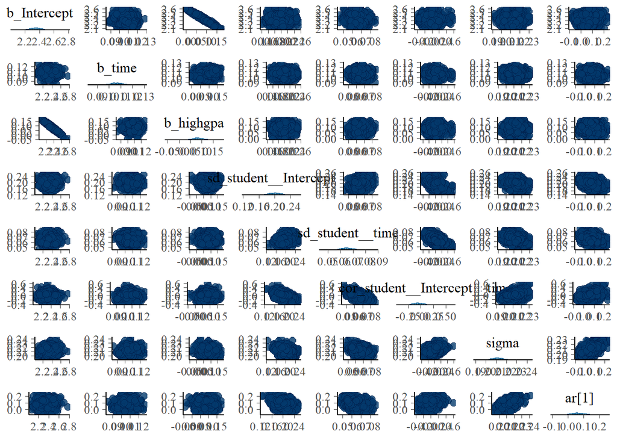

```r
pairs(MeanChange_Bayes_ARRes)
```

There is a pretty strong relation between the intercept and the regression coefficient of highgpa, but no serious issues (which would show up as red dots). If we make the estimation a bit more sensitive and run it for a little more iterations, things will probably be fine. The modelresults are already stored in `MeanChange_Bayes_ARRes`, but the code would be:

```r
MeanChange_Bayes_ARRes <- brm(gpa ~ 1 + time + highgpa + ar(p = 1) +
                              (1 + time | student), iter = 4000,
                              control = list(adapt_delta = 0.9), gpa)
```

We only have a warning about treedepth left. This is ok since it’s not a warning about validity but about efficiency. We could make the estimation more efficient, but it’s not needed so we’ll continue.

```r
summary(MeanChange_Bayes)
```

```
 Family: gaussian
  Links: mu = identity; sigma = identity
Formula: gpa ~ 1 + time + highgpa + (1 + time | student)
   Data: gpa (Number of observations: 1200)
  Draws: 4 chains, each with iter = 2000; warmup = 1000; thin = 1;
         total post-warmup draws = 4000

Group-Level Effects:
~student (Number of levels: 200)
                    Estimate Est.Error l-95% CI u-95% CI Rhat Bulk_ESS Tail_ESS
sd(Intercept)           0.21      0.02     0.18     0.24 1.00     2393     3109
sd(time)                0.07      0.01     0.06     0.08 1.00     1351     2211
cor(Intercept,time)    -0.09      0.10    -0.28     0.13 1.00     1146     2153

Population-Level Effects:
          Estimate Est.Error l-95% CI u-95% CI Rhat Bulk_ESS Tail_ESS
Intercept     2.34      0.09     2.16     2.52 1.00     2702     2792
time          0.11      0.01     0.09     0.12 1.00     2849     3197
highgpa       0.09      0.03     0.03     0.14 1.00     2727     2784

Family Specific Parameters:
      Estimate Est.Error l-95% CI u-95% CI Rhat Bulk_ESS Tail_ESS
sigma     0.21      0.01     0.20     0.22 1.00     3004     2901

Draws were sampled using sampling(NUTS). For each parameter, Bulk_ESS
and Tail_ESS are effective sample size measures, and Rhat is the potential
scale reduction factor on split chains (at convergence, Rhat = 1).
```

```r
summary(MeanChange_Bayes_ARRes)
```

[output not shown]

The AR parameter is reported under ‘Correlation Structures’. All results are very similar. This is because there isn’t a lot of autocorrelation (the AR parameter is only .07). So, we see there is little autocorrelation in this data (which makes sense given the sampling frequency in the data). For Intensive longitudinal data the AR will tend to be higher. If we want to explicitly model the AR effect, we need to lag the dependent variable and add it as a predictor. However, then you should remove time from the model. Otherwise, you end up with a very complicated model (the ALT-model), which is hard to interpret and therefore seldom used in practice. Instead, if there is a visible time-effect, you should first de-trend the data (which is just another way to control for time than including it as a predictor). There are different ways of de-trending the data. One could run a multilevel regression model with time as the only predictor and save the residuals. These residuals are the detrended data and can then be analyzed using the AR model. Another method calculates successive differences between observed scores after which these differences can be used as detrended data for the AR model. Finally, more advanced models would include the time-trend and AR part simultaneously in a way that the detrending and AR modeling of the detrended data is being done simultaneously.

# 3 Part 6: Mean Change and AR for Intensive Longitudinal Data

We will use self-generated data on 2 variables (Y1 and Y2) for 100 individuals each measured 50 times. The means of the 2 variables are 4 and 4.5 respectively, with SEs of .5. The correlation between the two variables is .3. The AR parameters are .4 and .3 respectively, while the two cross-lagged effects are .2 and .1. All cross-lagged parameters have SEs of .1. The residuals are standard normally distributed. Note that the lagged version of variable Y1 and Y2 are also included in the data (Y1lag and Y2lag).

## 3.1 - Assignment 1: Mean-change model with AR residuals

Run a multilevel model with time as a predictor and include AR residuals.

This model also takes a long time to run, so the results are already in the R workspace (`MeanChange_Bayes_ARRes2`). The code to run the model would be:

```r
MeanChange_Bayes_ARRes2 <- brm(Y1 ~ 1 + time + ar(p = 1) +
                                (1 + time | individual), iter = 4000,
                                control = list(adapt_delta = 0.9), VARData)
```

```r
summary(MeanChange_Bayes_ARRes2)
```

```
 Family: gaussian
  Links: mu = identity; sigma = identity
Formula: Y1 ~ 1 + time + ar(p = 1) + (1 + time | individual)
   Data: VARData (Number of observations: 5000)
  Draws: 4 chains, each with iter = 4000; warmup = 2000; thin = 1;
         total post-warmup draws = 8000

Correlation Structures:
      Estimate Est.Error l-95% CI u-95% CI Rhat Bulk_ESS Tail_ESS
ar[1]     0.51      0.02     0.48     0.54 1.00     9833     6103

Group-Level Effects:
~individual (Number of levels: 100)
                    Estimate Est.Error l-95% CI u-95% CI Rhat Bulk_ESS Tail_ESS
sd(Intercept)           0.35      0.08     0.20     0.50 1.00     4237     4588
sd(time)                0.01      0.00     0.00     0.01 1.01      610     1851
cor(Intercept,time)     0.46      0.36    -0.30     0.97 1.01      984     2496

Population-Level Effects:
          Estimate Est.Error l-95% CI u-95% CI Rhat Bulk_ESS Tail_ESS
Intercept     3.16      0.07     3.02     3.30 1.00     7486     6974
time          0.03      0.00     0.03     0.03 1.00     9896     7075

Family Specific Parameters:
      Estimate Est.Error l-95% CI u-95% CI Rhat Bulk_ESS Tail_ESS
sigma     1.07      0.01     1.05     1.09 1.00    14441     5162

Draws were sampled using sampling(NUTS). For each parameter, Bulk_ESS
and Tail_ESS are effective sample size measures, and Rhat is the potential
scale reduction factor on split chains (at convergence, Rhat = 1).
```

Clearly there is no substabtial systematic change over time, but there is a substantial amount of autocorrelation (ar[1] = .51 (.02)). Since there is no trend, we can use AR models. If there were a trend, you should control for it using one of de-trending methods mentioned above.

## 3.2 - Assignment 2: AR model

We continue with an AR model.

- Run the regular AR model. Is the intercept close to the true value of 4?
- Rerun the model with person-mean centered predictor. Is the intercept close to the true value of 4?

Again, to save time, the model results are already stored in the R workspace (`AR1` and `AR1_c`). The code to run the models is below.

```r
# Regular AR model
AR1 <- brm(Y1 ~ Y1lag + (1 + Y1lag | individual),
           iter = 5000, data = VARData,
           control = list(adapt_delta = 0.9))
```

```r
summary(AR1)
```

```
 Family: gaussian
  Links: mu = identity; sigma = identity
Formula: Y1 ~ Y1lag + (1 + Y1lag | individual)
   Data: VARData (Number of observations: 4900)
  Draws: 4 chains, each with iter = 5000; warmup = 2500; thin = 1;
         total post-warmup draws = 10000

Group-Level Effects:
~individual (Number of levels: 100)
                     Estimate Est.Error l-95% CI u-95% CI Rhat Bulk_ESS Tail_ESS
sd(Intercept)            0.33      0.08     0.17     0.48 1.00     1384     2549
sd(Y1lag)                0.07      0.02     0.02     0.11 1.01      617      663
cor(Intercept,Y1lag)    -0.47      0.35    -0.82     0.63 1.00      915     1018

Population-Level Effects:
          Estimate Est.Error l-95% CI u-95% CI Rhat Bulk_ESS Tail_ESS
Intercept     2.15      0.06     2.03     2.28 1.00     7618     7488
Y1lag         0.46      0.01     0.43     0.49 1.00     6580     6619

Family Specific Parameters:
      Estimate Est.Error l-95% CI u-95% CI Rhat Bulk_ESS Tail_ESS
sigma     1.02      0.01     1.00     1.04 1.00    10536     6527

Draws were sampled using sampling(NUTS). For each parameter, Bulk_ESS
and Tail_ESS are effective sample size measures, and Rhat is the potential
scale reduction factor on split chains (at convergence, Rhat = 1).
```

The intercept value is not close to the true mean. This is because the intercept in AR models can’t be interpreted as a mean. If we want means, we need to group-mean center.

```r
# AR model with person-mean centered predictor
VARData <- VARData %>%
  group_by(individual) %>%
  mutate(Y1lag_c = Y1lag - mean(Y1lag, na.rm=T),
         Y2lag_c = Y2lag - mean(Y2lag, na.rm=T))

AR1_c <- brm(Y1 ~ Y1lag_c + (1 + Y1lag_c | individual),
             iter = 5000, data = VARData,
             control = list(adapt_delta = 0.9))
```

```r
summary(AR1_c)
```

```
 Family: gaussian
  Links: mu = identity; sigma = identity
Formula: Y1 ~ Y1lag_c + (1 + Y1lag_c | individual)
   Data: VARData (Number of observations: 4900)
  Draws: 4 chains, each with iter = 5000; warmup = 2500; thin = 1;
         total post-warmup draws = 10000

Group-Level Effects:
~individual (Number of levels: 100)
                       Estimate Est.Error l-95% CI u-95% CI Rhat Bulk_ESS Tail_ESS
sd(Intercept)              0.56      0.04     0.48     0.65 1.01     1337     2713
sd(Y1lag_c)                0.09      0.02     0.05     0.13 1.00     2642     2290
cor(Intercept,Y1lag_c)     0.14      0.18    -0.21     0.49 1.00     5095     4112

Population-Level Effects:
          Estimate Est.Error l-95% CI u-95% CI Rhat Bulk_ESS Tail_ESS
Intercept     3.97      0.06     3.85     4.08 1.01      524     1555
Y1lag_c       0.43      0.02     0.40     0.46 1.00     6145     7161

Family Specific Parameters:
      Estimate Est.Error l-95% CI u-95% CI Rhat Bulk_ESS Tail_ESS
sigma     1.01      0.01     0.99     1.03 1.00    10426     6911

Draws were sampled using sampling(NUTS). For each parameter, Bulk_ESS
and Tail_ESS are effective sample size measures, and Rhat is the potential
scale reduction factor on split chains (at convergence, Rhat = 1).
```

Now the intercept value is much close to the mean. Note, however, that using sample means to person-mean center isn’t ideal since it doesn’t acknowledge the uncertainty in the means. ‘Latent-mean’ centering (where means are treated as random variables with distributions and thus uncertainty) is preferred. This is not available in R. We would have to write our own code (e.g., see the following STAN code https://experienced-sampler.netlify.app/post/stan-hierarchical-ar/#model) or use Mplus.